# Creditcard Analysis

DccLxxVii

November 26, 2019

# Load libraries

```r
suppressMessages(library(reshape2))
# suppressMessages(library(tidyverse))
suppressMessages(library(DataExplorer))
suppressMessages(library(ggplot2))
suppressMessages(library("gridExtra"))
library(grid)
library(ggplot2)
library(dplyr)
library(readr)
library("NbClust")
```

# 1. INTRODUCTION

Data Science assignment: EDA, Clustering and ANN

### DATA INTRODUCTION (SOURCE:KAGGLE)

The dataset contains transactions made by credit cards in September 2013 by European cardholders. This dataset presents transactions that occurred in two days, where we have 492 frauds out of 284,807 transactions. The dataset is highly unbalanced, the positive class (frauds) account for 0.172% of all transactions.

It contains only numerical input variables which are the result of a PCA transformation. Unfortunately, due to confidentiality issues, we cannot provide the original features and more background information about the data. Features V1, V2, … V28 are the principal components obtained with PCA, the only features which have not been transformed with PCA are ‘Time’ and ‘Amount’. Feature ‘Time’ contains the seconds elapsed between each transaction and the first transaction in the dataset. The feature ‘Amount’ is the transaction Amount, this feature can be used for example-dependant cost-senstive learning. Feature ‘Class’ is the response variable and it takes value 1 in case of fraud and 0 otherwise.

# 2. METHODS

## EXPLORATORY DATA ANALYSIS (EDA)

#### 1. Loading Data

```r
CC_Data <- read_csv("/home/dcclxxvii/Data/creditcard.csv")
```

##### 1a. Checking for missing values

Lets see if the data has missing values

```r
introduce(CC_Data)
```

| rows | columns | discrete_columns | continuous_columns | all_missing_columns | total_missing_values | complete_rows | total_observations | memory_usage |
| --- | --- | --- | --- | --- | --- | --- | --- | --- |
| 284807 | 31 | 0 | 31 | 0 | 0 | 284807 | 8829017 | 70638808 |

```r
NA
```

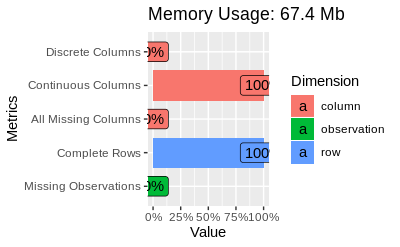

```r
plot_intro(CC_Data)
```

##### Determining the missing value

```r
for (Var in names(CC_Data)) {
    missing <- sum(is.na(CC_Data[,Var]))
    if (missing > 0) {
        print(c(Var,missing))
    }
}
```

##### 1b. Checking for constant features

```r
flag <- FALSE

for (f in names(CC_Data)) {
  if (length(unique(CC_Data[[f]])) == 1) {
    cat(f, "\n")
     flag <- TRUE
  }
}

if (flag == FALSE){
     print ("no variable found to be constant")
}
```

```
[1] "no variable found to be constant"
```

##### 1c. Checking for equal columns

```r
flag <- FALSE
features_pair <- combn(names(CC_Data), 2, simplify = F)
for(pair in features_pair) {
  f1 <- pair[1]
  f2 <- pair[2]

      if (all(CC_Data[[f1]] == CC_Data[[f2]])) {
      cat(f1, "and", f2, "are equals.\n")
           flag <- TRUE
    }
}

if (flag == FALSE){
     print ("No variables found as equal")
}
```

```
[1] "No variables found as equal"
```

##### 1d. Data cleansing

```r
CC_Data=na.omit((CC_Data))
```

#### 2. Summary Statistics

First lets look at the summary statistics of all variable

```r
summary(CC_Data)
```

```
      Time              V1                  V2                  V3                 V4                 V5
 Min.   :     0   Min.   :-56.40751   Min.   :-72.71573   Min.   :-48.3256   Min.   :-5.68317   Min.   :-113.74331
 1st Qu.: 54202   1st Qu.: -0.92037   1st Qu.: -0.59855   1st Qu.: -0.8904   1st Qu.:-0.84864   1st Qu.:  -0.69160
 Median : 84692   Median :  0.01811   Median :  0.06549   Median :  0.1799   Median :-0.01985   Median :  -0.05434
 Mean   : 94814   Mean   :  0.00000   Mean   :  0.00000   Mean   :  0.0000   Mean   : 0.00000   Mean   :   0.00000
 3rd Qu.:139320   3rd Qu.:  1.31564   3rd Qu.:  0.80372   3rd Qu.:  1.0272   3rd Qu.: 0.74334   3rd Qu.:   0.61193
 Max.   :172792   Max.   :  2.45493   Max.   : 22.05773   Max.   :  9.3826   Max.   :16.87534   Max.   :  34.80167
       V6                 V7                 V8                  V9                 V10                 V11
 Min.   :-26.1605   Min.   :-43.5572   Min.   :-73.21672   Min.   :-13.43407   Min.   :-24.58826   Min.   :-4.79747
 1st Qu.: -0.7683   1st Qu.: -0.5541   1st Qu.: -0.20863   1st Qu.: -0.64310   1st Qu.: -0.53543   1st Qu.:-0.76249
 Median : -0.2742   Median :  0.0401   Median :  0.02236   Median : -0.05143   Median : -0.09292   Median :-0.03276
 Mean   :  0.0000   Mean   :  0.0000   Mean   :  0.00000   Mean   :  0.00000   Mean   :  0.00000   Mean   : 0.00000
 3rd Qu.:  0.3986   3rd Qu.:  0.5704   3rd Qu.:  0.32735   3rd Qu.:  0.59714   3rd Qu.:  0.45392   3rd Qu.: 0.73959
 Max.   : 73.3016   Max.   :120.5895   Max.   : 20.00721   Max.   : 15.59500   Max.   : 23.74514   Max.   :12.01891
      V12                V13                V14                V15                V16                 V17
 Min.   :-18.6837   Min.   :-5.79188   Min.   :-19.2143   Min.   :-4.49894   Min.   :-14.12985   Min.   :-25.16280
 1st Qu.: -0.4056   1st Qu.:-0.64854   1st Qu.: -0.4256   1st Qu.:-0.58288   1st Qu.: -0.46804   1st Qu.: -0.48375
 Median :  0.1400   Median :-0.01357   Median :  0.0506   Median : 0.04807   Median :  0.06641   Median : -0.06568
 Mean   :  0.0000   Mean   : 0.00000   Mean   :  0.0000   Mean   : 0.00000   Mean   :  0.00000   Mean   :  0.00000
 3rd Qu.:  0.6182   3rd Qu.: 0.66251   3rd Qu.:  0.4931   3rd Qu.: 0.64882   3rd Qu.:  0.52330   3rd Qu.:  0.39968
 Max.   :  7.8484   Max.   : 7.12688   Max.   : 10.5268   Max.   : 8.87774   Max.   : 17.31511   Max.   :  9.25353
      V18                 V19                 V20                 V21                 V22
 Min.   :-9.498746   Min.   :-7.213527   Min.   :-54.49772   Min.   :-34.83038   Min.   :-10.933144
 1st Qu.:-0.498850   1st Qu.:-0.456299   1st Qu.: -0.21172   1st Qu.: -0.22839   1st Qu.: -0.542350
 Median :-0.003636   Median : 0.003735   Median : -0.06248   Median : -0.02945   Median :  0.006782
 Mean   : 0.000000   Mean   : 0.000000   Mean   :  0.00000   Mean   :  0.00000   Mean   :  0.000000
 3rd Qu.: 0.500807   3rd Qu.: 0.458949   3rd Qu.:  0.13304   3rd Qu.:  0.18638   3rd Qu.:  0.528554
 Max.   : 5.041069   Max.   : 5.591971   Max.   : 39.42090   Max.   : 27.20284   Max.   : 10.503090
      V23                 V24                V25                 V26                V27
 Min.   :-44.80774   Min.   :-2.83663   Min.   :-10.29540   Min.   :-2.60455   Min.   :-22.565679
 1st Qu.: -0.16185   1st Qu.:-0.35459   1st Qu.: -0.31715   1st Qu.:-0.32698   1st Qu.: -0.070840
 Median : -0.01119   Median : 0.04098   Median :  0.01659   Median :-0.05214   Median :  0.001342
 Mean   :  0.00000   Mean   : 0.00000   Mean   :  0.00000   Mean   : 0.00000   Mean   :  0.000000
 3rd Qu.:  0.14764   3rd Qu.: 0.43953   3rd Qu.:  0.35072   3rd Qu.: 0.24095   3rd Qu.:  0.091045
 Max.   : 22.52841   Max.   : 4.58455   Max.   :  7.51959   Max.   : 3.51735   Max.   : 31.612198
      V28                Amount             Class
 Min.   :-15.43008   Min.   :    0.00   Min.   :0.000000
 1st Qu.: -0.05296   1st Qu.:    5.60   1st Qu.:0.000000
 Median :  0.01124   Median :   22.00   Median :0.000000
 Mean   :  0.00000   Mean   :   88.35   Mean   :0.001728
 3rd Qu.:  0.07828   3rd Qu.:   77.17   3rd Qu.:0.000000
 Max.   : 33.84781   Max.   :25691.16   Max.   :1.000000
```

##### Factoring the Class variable

```r
# Creating factor
CC_Data <- CC_Data %>%
     mutate(Class = as.factor(Class))
levels(CC_Data$Class) <- c('Normal', 'Fraud')

#ploting
table(CC_Data$Class)
```

```
Normal  Fraud
284315    492
```

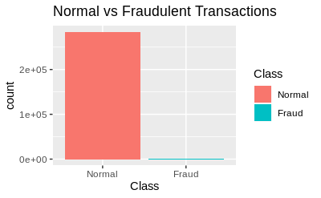

```r
ggplot(CC_Data)+
     geom_bar(aes(x = Class, fill = Class))+ggtitle("Normal vs Fraudulent Transactions")
```

- The data is highly unbalanced as there are 492 fraud transactions compared to 284,315 clean transactions

```r
fraudData <- subset(CC_Data,Class=='Fraud')
notFraudData <- subset(CC_Data,Class=='Normal')
```

#### 3. Exploring if Fraud Transactions occur at specific time?

Time is defined as number of seconds elapsed between this transaction and the first transaction in the dataset

```r
# create new variable: night, based on Time variable
CC_Data_time<-na.omit(read_csv("/home/dcclxxvii/Data/creditcard.csv"))
CC_Data_time$Night <- as.factor((floor(CC_Data_time$Time/60/60)%%24 <= 9)*1)
```

#### Transactions divided per time of day

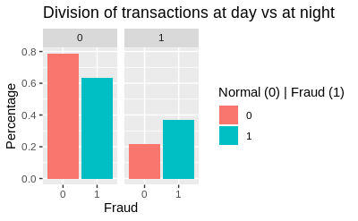

```r
toPlot <- CC_Data_time
toPlot$factClass <- as.factor(CC_Data_time$Class)
toPlot <- table(toPlot$Night, toPlot$factClass)
toPlot <- melt(toPlot)
toPlot$value[toPlot$Var2==0] = toPlot$value[toPlot$Var2==0]/sum(toPlot$value[toPlot$Var2==0])
toPlot$value[toPlot$Var2==1] = toPlot$value[toPlot$Var2==1]/sum(toPlot$value[toPlot$Var2==1])
names(toPlot) <- c("IsNight", "Fraud", "Percentage")
toPlot$Fraud <-as.factor(toPlot$Fraud)
ggplot(toPlot, aes(x=Fraud, y=Percentage, fill=Fraud))+geom_bar(stat="identity")+
  facet_grid(~IsNight)+
  ggtitle("Division of transactions at day vs at night")+
  scale_fill_discrete(name="Normal (0) | Fraud (1)")
```

- Fraud transactions are more likely to happen at night, comparing to normal transactions.
- Normal transactions are more likely to happen during the day than during the night
- Fraud transactions are more likely to happen during the day than during the night

#### Normal and Fraud transactions variation over time

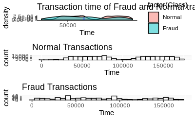

```r
p1 <- ggplot(notFraudData, aes(x = Time)) +
        geom_histogram(fill="light blue", colour = "black") + labs(title=expression("Normal Transactions"))

p2 <- ggplot(fraudData, aes(x = Time)) +
        geom_histogram(fill="light green", colour = "black") + labs(title=expression("Fraud Transactions"))

p3 <- ggplot(data = CC_Data,aes(x=Time,fill=factor(Class)))+geom_density(alpha=0.5)+
  geom_vline(aes(xintercept=mean(Time[Class=="Not Fraud"])),color="red",linetype="dashed",lwd=0.5)+
  geom_vline(aes(xintercept=mean(Time[Class=="Fraud"])),color="blue",linetype="dashed",lwd=0.5)+
       scale_x_continuous(breaks = seq(50000,100000,150000))+
  xlab(label = "Time") +
  ggtitle("Transaction time of Fraud and Normal transactions")+
  theme_classic()

grid.arrange(p3, p1, p2)
```

- We can clearly see that normal transactions follow a cyclical period. Therefore, if large number of transaction show up in low acitivity period it can raise an alarm

#### 4. Exploring if Fraud Transactions are related with amount of transaction?

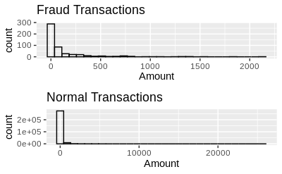

```r
p3 <- ggplot(fraudData, aes(x = Amount)) +
        geom_histogram(fill="light blue", colour = "black") + labs(title=expression("Fraud Transactions"))

p4 <- ggplot(notFraudData, aes(x = Amount)) +
        geom_histogram(fill="light green", colour = "black") + labs(title=expression("Normal Transactions"))

grid.arrange(p3, p4)
```

- No particular insights here, most of the transactions appear to be of small amount for both fraud and clean transactions. Lets further look into it by looking at its percentiles

#### Cumulative quintiles for Fraud and Normal transactions

```r
##Normal Transactions
quantile(notFraudData$Amount, seq(0, 1, by=.2))
```

```
      0%      20%      40%      60%      80%     100%
    0.00     3.58    13.03    37.00   100.00 25691.16
```

```r
##Fraud Transactions
quantile(fraudData$Amount, seq(0, 1, by=.2))
```

```
      0%      20%      40%      60%      80%     100%
   0.000    1.000    2.000   39.992  152.342 2125.870
```

- Clearly 60% of the transactions are of amount less than ~$40. Lets zoom into the transactions under $50 to see if there is an anomaly between fraud and clean transactions

#### Cumulative % graphs for Normal and Fraud transaction amounts

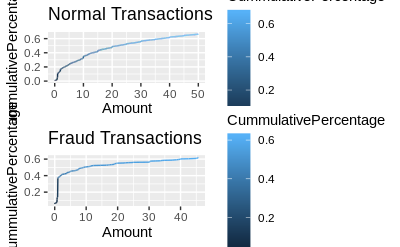

```r
tab <- melt(table(CC_Data$Amount[CC_Data$Class=='Normal']))
tab$CummulativePercentage <- cumsum(tab$value) / sum(tab$value) # cumulative Frequency
names(tab)[1] <- "Amount"
p5 <- ggplot(tab[tab$Amount<50,], aes(x=Amount, y=CummulativePercentage, color=CummulativePercentage))+
  geom_line()+ggtitle("Normal Transactions")

tab <- melt(table(CC_Data$Amount[CC_Data$Class=='Fraud']))
tab$CummulativePercentage <- cumsum(tab$value) / sum(tab$value)
names(tab)[1] <- "Amount"
p6 <- ggplot(tab[tab$Amount<50,], aes(x=Amount, y=CummulativePercentage, color=CummulativePercentage))+
  geom_line()+ggtitle("Fraud Transactions")

grid.arrange(p5, p6)
```

#### 5. Exploring if Fraud Transactions are related with amount and time of transaction?

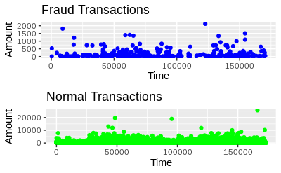

```r
p7<-ggplot(fraudData, aes(x=Time, y=Amount)) +
  geom_point(colour="blue") + ggtitle("Fraud Transactions")

p8<-ggplot(notFraudData, aes(x=Time, y=Amount)) +
  geom_point(colour="green")+ggtitle("Normal Transactions")

grid.arrange(p7, p8)
```

- Again, no particular anomaly here between fraud and normal transactions.

#### 6. Which variables explain the fraud transactions?

**We will use several methods to explore which variables can help in detecting the fraud transaction**

First,we need to look at the coorelation of all variablesto find a relation :

##### Correlation map

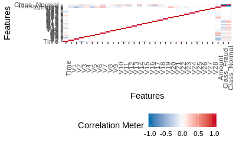

```r
plot_correlation(CC_Data, maxcat = 8L)
```

- None of the V1 to V28 PCA components have any correlation to each other.
- Little to no correlation between variables indicates that it is highly likely that ** data is pca transformed**
- Time has some correlations with V components but not with Amount.
- Amount also has some correlations with V components but not with Time.
- Class has some positive and negative correlations with the V components but has no significant correlation with Time and Amount.

##### Comparison of mean of variables by Fraud vs Normal transactions

```r
skew <- sum(as.numeric(CC_Data$Class))/nrow(CC_Data)
mugood <- apply(notFraudData[sample(rownames(notFraudData), size = as.integer(skew *nrow(CC_Data)), replace = T), -c(1, 30, 31)], 2, mean)
muanom <- apply(fraudData[, -c(1, 30, 31)], 2, mean)
plot(muanom, col = "blue", xlab = "Features", ylab = "Mean")
lines(muanom, col = "blue", lwd = 2)
```

```r
points(mugood, col = "green")
lines(mugood, col = "green", lwd = 2)
```

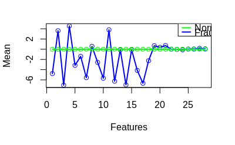

```r
legend("topright", legend = c("Normal", "Fraud"), lty = c(1,1), col = c("green", "blue"), lwd = c(2,2))
```

- Mean values of variables for fraud transactions are different than for normal transactions for most of the variables.
- Mean values for the normal transacitons dont differ.
- Mean values for fraud transactions differ alot.

**Let’s look at the box plot for all the variables:**

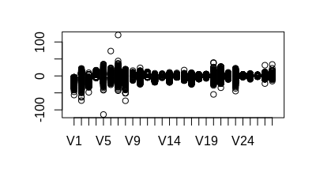

```r
boxplot(CC_Data[2:29])
```

- It is worth noticing that V13, V15, V19, and maybe V24 look very symmetrical. We will look at them in detail below
- Outliers appear to be a problem. However, outliers also help in detecting anomolies so we will not treat them.

# 3. K-Means Clustering

#### Data Preparation

- To prepare the dataset for clustering, we center and scale the columns using scale(x, center = TRUE, scale = TRUE), where x is a matrix or dataframe. -But first subsetting is required.

```r
CC_Data <- read_csv("/home/dcclxxvii/Data/creditcard.csv")
CC_Data <- CC_Data[1:1000,]

head(CC_Data, n=3)
```

| Time | V1 | V2 | V3 | V4 | V5 | V6 | V7 | V8 | V9 | V10 | V11 | V12 | V13 | V14 | V15 | V16 | V17 | V18 | V19 | V20 | V21 | V22 | V23 | V24 | V25 | V26 | V27 | V28 | Amount | … |
| --- | --- | --- | --- | --- | --- | --- | --- | --- | --- | --- | --- | --- | --- | --- | --- | --- | --- | --- | --- | --- | --- | --- | --- | --- | --- | --- | --- | --- | --- | --- |
| 0 | -1.359807 | -0.07278117 | 2.5363467 | 1.3781552 | -0.33832077 | 0.46238778 | 0.23959855 | 0.09869790 | 0.3637870 | 0.09079417 | -0.5515995 | -0.61780086 | -0.9913898 | -0.3111694 | 1.4681770 | -0.4704005 | 0.2079712 | 0.02579058 | 0.403993 | 0.25141210 | -0.01830678 | 0.2778376 | -0.1104739 | 0.06692807 | 0.1285394 | -0.1891148 | 0.133558377 | -0.02105305 | 149.62 | … |
| 0 | 1.191857 | 0.26615071 | 0.1664801 | 0.4481541 | 0.06001765 | -0.08236081 | -0.07880298 | 0.08510165 | -0.2554251 | -0.16697441 | 1.6127267 | 1.06523531 | 0.4890950 | -0.1437723 | 0.6355581 | 0.4639170 | -0.1148047 | -0.18336127 | -0.145783 | -0.06908314 | -0.22577525 | -0.6386720 | 0.1012880 | -0.33984648 | 0.1671704 | 0.1258945 | -0.008983099 | 0.01472417 | 2.69 | … |
| 1 | -1.358354 | -1.34016307 | 1.7732093 | 0.3797796 | -0.50319813 | 1.80049938 | 0.79146096 | 0.24767579 | -1.5146543 | 0.20764287 | 0.6245015 | 0.06608369 | 0.7172927 | -0.1659459 | 2.3458649 | -2.8900832 | 1.1099694 | -0.12135931 | -2.261857 | 0.52497973 | 0.24799815 | 0.7716794 | 0.9094123 | -0.68928096 | -0.3276418 | -0.1390966 | -0.055352794 | -0.05975184 | 378.66 | … |

```r
NA
```

```r
CC_Data_scale <- scale(CC_Data[-1])

head(CC_Data_scale, n=3)
```

```
             V1          V2         V3        V4          V5        V6         V7        V8         V9         V10
[1,] -0.8897564 -0.25751959  1.6198325 0.9037574 -0.28133736  0.250743  0.1704484 0.1810515  0.4094781  0.05620284
[2,]  1.0436726  0.03614547 -0.6892930 0.1643559  0.08588446 -0.190344 -0.2084098 0.1656586 -0.2850298 -0.21350271
[3,] -0.8886554 -1.35563340  0.8762548 0.1099945 -0.43333517  1.334222  0.8270960 0.3497149 -1.6973805  0.17846266
            V11        V12        V13         V14       V15        V16         V17         V18        V19        V20
[1,] -0.6366587 -1.2990747 -0.9950579 -0.13361643 1.3268002 -0.4049732  0.36900381  0.25152645  0.4726455  0.3592343
[2,]  1.4924796  1.2489046  0.6892480  0.07703850 0.4145599  0.7413643 -0.07946432 -0.01995209 -0.2167268 -0.2245737
[3,]  0.5203211 -0.2637294  0.9488621  0.04913488 2.2884194 -3.3737419  1.62224919  0.06052629 -2.8701033  0.8575599
             V21        V22        V23        V24         V25        V26         V27          V28     Amount
[1,] -0.03611086  0.6576310 -0.1989770  0.1087149  0.03960566 -0.4564359  0.37756617 -0.008675744  0.4442179
[2,] -0.36505408 -0.8416019  0.3946907 -0.5506517  0.12959747  0.2116979 -0.06842301  0.125032873 -0.3403615
[3,]  0.38611813  1.4654610  2.6602405 -1.1170722 -1.02307765 -0.3503473 -0.21350627 -0.153302993  1.6672498
           Class
[1,] -0.04474376
[2,] -0.04474376
[3,] -0.04474376
```

#### Dtermine OPtimal Number of Columns

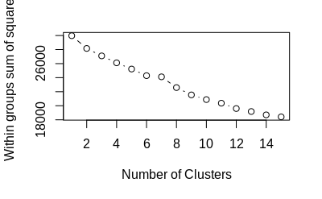

```r
wssplot <- function(data, nc=15, seed=1234){
               wss <- (nrow(data)-1)*sum(apply(data,2,var))
               for (i in 2:nc){
                    set.seed(seed)
                    wss[i] <- sum(kmeans(data, centers=i)$withinss)}
                plot(1:nc, wss, type="b", xlab="Number of Clusters",
                     ylab="Within groups sum of squares")}

wssplot(CC_Data_scale)
```

#### Deterimine optimal number of clusters

-NbClust() is used to determine the best clustering scheme from the different results obtained by varying all combinations of number of clusters and distance methods.

[output not shown]

```
*** : The Hubert index is a graphical method of determining the number of clusters.
                In the plot of Hubert index, we seek a significant knee that corresponds to a
                significant increase of the value of the measure i.e the significant peak in Hubert
                index second differences plot.
```

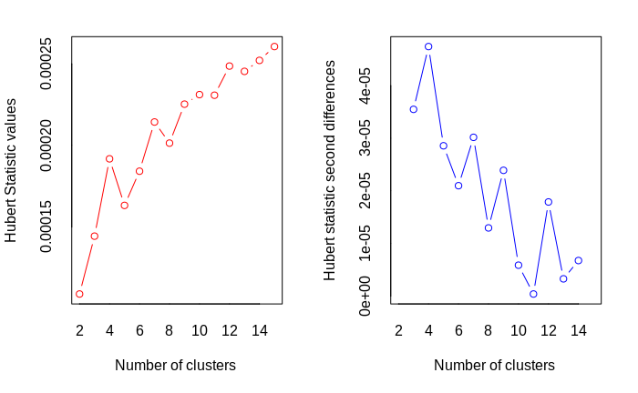

```
*** : The D index is a graphical method of determining the number of clusters.
                In the plot of D index, we seek a significant knee (the significant peak in Dindex
                second differences plot) that corresponds to a significant increase of the value of
                the measure.

* Among all indices:
* 8 proposed 2 as the best number of clusters
* 4 proposed 3 as the best number of clusters
* 1 proposed 5 as the best number of clusters
* 4 proposed 10 as the best number of clusters
* 1 proposed 11 as the best number of clusters
* 3 proposed 12 as the best number of clusters
* 3 proposed 15 as the best number of clusters

                   ***** Conclusion *****

* According to the majority rule, the best number of clusters is  2
```

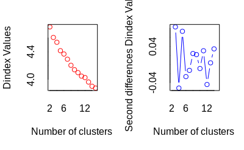

```r
set.seed(1234)
nc <- NbClust(CC_Data_scale, min.nc=2, max.nc=15, method="kmeans")
```

-Optimal number of clusters is determined as the number of clusters selected by the highest number of criteria. This can be visualized as a barplot:

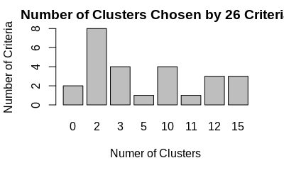

```r
barplot(table(nc$Best.n[1,]),
          xlab="Numer of Clusters", ylab="Number of Criteria",
          main="Number of Clusters Chosen by 26 Criteria")
```

#### K-means cluster analysis

-kmeans() is used to obtain the final clustering solution.

```r
cc_km <- kmeans(CC_Data, 2, nstart=25)
```

-cc_km$size returns the number of items in each cluster

```r
cc_km$size
```

```
[1] 490 510
```

-cc_km$centers returns the central value for each cluster

```r
cc_km$centers
```

```
      Time         V1        V2        V3
1 569.8367 -0.2189269 0.2757030 0.8875515
2 180.8980 -0.1534649 0.1751748 0.8607933
         V4          V5         V6
1 0.1006352 -0.08985508 0.05302147
2 0.3767059  0.02134264 0.24850231
          V7          V8          V9
1 0.08866023 -0.07344094  0.01790364
2 0.10373743 -0.04948253 -0.01974491
         V10        V11       V12
1 0.01395252 0.08918896 0.2168483
2 0.05929822 0.10172261 0.2628063
          V13        V14       V15
1 -0.15118977 -0.1918713 0.2893407
2 -0.08365258 -0.2175962 0.2262833
         V16         V17        V18
1 -0.1090175 -0.05354517 -0.1454615
2 -0.1704122 -0.06151899 -0.1896347
           V19        V20          V21
1  0.057158241 0.05219072  0.016917568
2 -0.001863656 0.05613422 -0.007491829
         V22         V23          V24
1 -0.1408448 -0.04261386 -0.009479210
2 -0.1081780 -0.03650549  0.008832941
         V25         V26         V27
1 0.08743294 0.044409843 0.007277616
2 0.13469721 0.008476702 0.018273283
          V28   Amount       Class
1 -0.02022128 60.30522 0.004081633
2 -0.01730040 72.31514 0.000000000
```

```r
aggregate(CC_Data[-1], by=list(cluster=cc_km$cluster),mean)
```

| cluster | V1 | V2 | V3 | V4 | V5 | V6 | V7 | V8 | V9 | V10 | V11 | V12 | V13 | V14 | V15 | V16 | V17 | V18 | V19 | V20 | V21 | V22 | V23 | V24 | V25 | V26 | V27 | V28 | Amount | … |
| --- | --- | --- | --- | --- | --- | --- | --- | --- | --- | --- | --- | --- | --- | --- | --- | --- | --- | --- | --- | --- | --- | --- | --- | --- | --- | --- | --- | --- | --- | --- |
| 1 | -0.2189269 | 0.2757030 | 0.8875515 | 0.1006352 | -0.08985508 | 0.05302147 | 0.08866023 | -0.07344094 | 0.01790364 | 0.01395252 | 0.08918896 | 0.2168483 | -0.15118977 | -0.1918713 | 0.2893407 | -0.1090175 | -0.05354517 | -0.1454615 | 0.057158241 | 0.05219072 | 0.016917568 | -0.1408448 | -0.04261386 | -0.009479210 | 0.08743294 | 0.044409843 | 0.007277616 | -0.02022128 | 60.30522 | … |
| 2 | -0.1534649 | 0.1751748 | 0.8607933 | 0.3767059 | 0.02134264 | 0.24850231 | 0.10373743 | -0.04948253 | -0.01974491 | 0.05929822 | 0.10172261 | 0.2628063 | -0.08365258 | -0.2175962 | 0.2262833 | -0.1704122 | -0.06151899 | -0.1896347 | -0.001863656 | 0.05613422 | -0.007491829 | -0.1081780 | -0.03650549 | 0.008832941 | 0.13469721 | 0.008476702 | 0.018273283 | -0.01730040 | 72.31514 | … |

# 4. ANN (Artificial Neural Network)

- Load the neuralnet package into the system.

```r
library("neuralnet")
```

-Use the scaled data

-The following code splits the dataset into a training set consisting of 70% of the data and a test set containing 30% of the data.

```r
ind <- sample(2, nrow(CC_Data_scale), replace = TRUE, prob = c(0.7, 0.3))
train.data <- as.data.frame(CC_Data_scale[ind == 1, ])
test.data <- as.data.frame(CC_Data_scale[ind == 2, ])
```

```r
nn <- neuralnet(formula = Class ~ V1 + V3 + V15 + V18 + V11 + V12 +V5,
                data = train.data, hidden = 2, linear.output = FALSE)
```

-Summary of the model

```r
summary(nn)
```

```
                    Length Class      Mode
call                   5   -none-     call
response             707   -none-     numeric
covariate           4949   -none-     numeric
model.list             2   -none-     list
err.fct                1   -none-     function
act.fct                1   -none-     function
linear.output          1   -none-     logical
data                  30   data.frame list
exclude                0   -none-     NULL
net.result             1   -none-     list
weights                1   -none-     list
generalized.weights    1   -none-     list
startweights           1   -none-     list
result.matrix         22   -none-     numeric
```

-We will examine the following properties: the response values, result matrix, and net result probabilities. -Show the values of the dependent variable for the first 21 observations.

```r
nn$response[1:21]
```

```
 [1] -0.04474376 -0.04474376 -0.04474376 -0.04474376 -0.04474376 -0.04474376 -0.04474376 -0.04474376 -0.04474376 -0.04474376 -0.04474376 -0.04474376 -0.04474376 -0.04474376
[15] -0.04474376 -0.04474376 -0.04474376 -0.04474376 -0.04474376 -0.04474376 -0.04474376
```

-Show the probability for the first 21 records.

```r
nn$net.result[[1]][1:21]
```

```
 [1] 4.925813e-06 7.974870e-07 3.157286e-07 3.245432e-07 3.318464e-07 3.147952e-07 3.438728e-07 3.102755e-07 3.096085e-07 4.803175e-07 3.095814e-07 3.221965e-07 8.836570e-07
[14] 3.177829e-07 3.135017e-07 3.165797e-07 3.899568e-07 3.096757e-07 3.097042e-07 3.096159e-07 3.096941e-07
```

-Show the network result matrix, which includes information on the number of training steps, the error, and the weights.

```r
nn$result.matrix
```

```
                              [,1]
error                 455.58007545
reached.threshold       0.00966983
steps                 135.00000000
Intercept.to.1layhid1   7.92886858
V1.to.1layhid1          1.35586761
V3.to.1layhid1         -0.12502575
V15.to.1layhid1        -1.39011750
V18.to.1layhid1        -1.25939323
V11.to.1layhid1        -0.92145839
V12.to.1layhid1         1.05342480
V5.to.1layhid1         -0.35588318
Intercept.to.1layhid2  -7.69098651
V1.to.1layhid2         -1.54750355
V3.to.1layhid2          0.55686326
V15.to.1layhid2         0.39044348
V18.to.1layhid2         1.19265636
V11.to.1layhid2        -0.55131447
V12.to.1layhid2        -2.26784565
V5.to.1layhid2          0.10521009
Intercept.to.Class     -1.10649168
1layhid1.to.Class     -13.88177012
1layhid2.to.Class      11.56109414
```

-Create a visualization of the neural network.

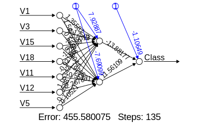

```r
plot(nn)
```

- Compute the predicted values for the training set

```r
mypredict <- compute(nn, nn$covariate)$net.result
mypredict <- apply(mypredict, c(1), round)
```

-Show the first 21 predicted values.

```r
mypredict[1:21]
```

```
 [1] 0 0 0 0 0 0 0 0 0 0 0 0 0 0 0 0 0 0 0 0 0
```

-Create the confusion matrix on the training data.

```r
table(mypredict, train.data$Class, dnn = c("Predicted", "Actual"))
```

```
         Actual
Predicted -0.0447437594309646 22.3271359560513
        0                 705                0
        1                   0                2
```

-Computes the predicted values for the test set and rounds them to the nearest integer (either 0 or 1).

```r
testPred <- compute(nn, test.data)$net.result
testPred <- apply(testPred, c(1), round)
```

-Create the confusion matrix on the test data.

```r
table(testPred, test.data$Class, dnn = c("Predicted", "Actual"))
```

```
         Actual
Predicted -0.0447437594309646
        0                 292
        1                   1
```